# Simulation Study: Effect of Sample Size on Clustering Structure Recovery

Your Name

2025-07-26

# Executive Summary

This simulation study extends our previous analysis by investigating how **sample size** affects the ability to recover known clustering structures. We examine the interaction between sample size and cluster separation to understand when additional data can compensate for poor cluster separation.

**Key Questions**: 1. Does the critical separation threshold depend on sample size? 2. Can larger samples recover structure at lower separations? 3. Is there a minimum sample size below which even well-separated structures cannot be recovered? 4. How does sample size affect the bimodal behaviour observed at intermediate separations?

# 1. Methods

## 1.1 Experimental Design

We use the same two-structure data generation process as before: - **Structure 1**: 3 clusters in dimensions 1-5 - **Structure 2**: 4 clusters in dimensions 6-10

### Experimental Grid:

# 2. Implementation

```r
# Load required libraries
library(mvtnorm)      # For multivariate normal data generation
library(cluster)      # For PAM clustering
library(mclust)       # For model-based clustering
library(ggplot2)      # For visualisation
library(dplyr)        # For data manipulation
library(tidyr)        # For data reshaping
library(viridis)      # For colour scales
library(gridExtra)    # For arranging plots

# Set seed for reproducibility
set.seed(42)
```

```r
# Set up caching directory
cache_dir <- "sample_size_simulation_cache"
if (!dir.exists(cache_dir)) {
  dir.create(cache_dir)
  cat("Created cache directory:", cache_dir, "\n")
}

# Function to generate cache filename for a specific condition
get_cache_filename <- function(n_samples, separation_factor) {
  filename <- sprintf("results_n%d_sep%.1f.rds", n_samples, separation_factor)
  file.path(cache_dir, filename)
}

# Function to check if results exist for a specific condition
check_condition_cache <- function(n_samples, separation_factor) {
  cache_file <- get_cache_filename(n_samples, separation_factor)
  file.exists(cache_file)
}

# Function to save results for a specific condition
save_condition_results <- function(results, n_samples, separation_factor) {
  cache_file <- get_cache_filename(n_samples, separation_factor)
  saveRDS(results, cache_file)
}

# Function to load results for a specific condition
load_condition_results <- function(n_samples, separation_factor) {
  cache_file <- get_cache_filename(n_samples, separation_factor)
  if (file.exists(cache_file)) {
    return(readRDS(cache_file))
  } else {
    return(NULL)
  }
}
```

```r
# Experimental grid
sample_sizes <- c(50, 100, 250, 500, 1000, 2000)
separation_factors <- c(3.0, 2.0, 1.0)
n_replications <- 25

# Clustering structures (same as before)
n_clusters_1 <- 3
n_clusters_2 <- 4
cluster_props_1 <- c(0.4, 0.35, 0.25)
cluster_props_2 <- c(0.3, 0.25, 0.25, 0.2)
cluster_variance <- 0.3

# Ground truth structure labels for dimensions
true_structure_labels <- c(rep(1, 5), rep(2, 5))

# Calculate total number of conditions
n_conditions <- length(sample_sizes) * length(separation_factors)
cat("Experimental design:\n")
```

```
## Experimental design:
```

```r
cat("- Sample sizes:", paste(sample_sizes, collapse=", "), "\n")
```

```
## - Sample sizes: 50, 100, 250, 500, 1000, 2000
```

```r
cat("- Separation factors:", paste(separation_factors, collapse=", "), "σ\n")
```

```
## - Separation factors: 3, 2, 1 σ
```

```r
cat("- Total conditions:", n_conditions, "\n")
```

```
## - Total conditions: 18
```

```r
cat("- Replications per condition:", n_replications, "\n")
```

```
## - Replications per condition: 25
```

```r
cat("- Total simulation runs:", n_conditions * n_replications, "\n")
```

```
## - Total simulation runs: 450
```

```r
# Reuse data generation functions from previous analysis
generate_cluster_means <- function(separation_factor, cluster_variance) {
  base_separation <- separation_factor * sqrt(cluster_variance)

  means_1 <- list(
    cluster_1 = c(-1, -1.3, -1.2, -1.5, -1.1) * base_separation,
    cluster_2 = c(1, 1.3, 1.2, 1.5, 1.1) * base_separation,
    cluster_3 = c(0, 0, 0, 0, 0)
  )

  means_2 <- list(
    cluster_1 = c(-1.3, -1, -1.25, -1.4, -1.2) * base_separation,
    cluster_2 = c(1.3, 1, 1.25, 1.4, 1.2) * base_separation,
    cluster_3 = c(-0.3, 0.3, -0.4, 0.4, -0.25) * base_separation,
    cluster_4 = c(0.3, -0.3, 0.4, -0.4, 0.25) * base_separation
  )

  return(list(means_1 = means_1, means_2 = means_2))
}

generate_dataset <- function(separation_factor, cluster_variance, n_samples,
                           cluster_props_1, cluster_props_2) {

  cluster_1_assignments <- sample(1:n_clusters_1, n_samples,
                                 replace = TRUE, prob = cluster_props_1)
  cluster_2_assignments <- sample(1:n_clusters_2, n_samples,
                                 replace = TRUE, prob = cluster_props_2)

  means_list <- generate_cluster_means(separation_factor, cluster_variance)
  means_1 <- means_list$means_1
  means_2 <- means_list$means_2

  covs_1 <- list(
    cluster_1 = diag(rep(cluster_variance, 5)),
    cluster_2 = diag(rep(cluster_variance, 5)),
    cluster_3 = diag(rep(cluster_variance, 5))
  )

  covs_2 <- list(
    cluster_1 = diag(rep(cluster_variance, 5)),
    cluster_2 = diag(rep(cluster_variance, 5)),
    cluster_3 = diag(rep(cluster_variance, 5)),
    cluster_4 = diag(rep(cluster_variance, 5))
  )

  data_matrix <- matrix(NA, nrow = n_samples, ncol = 10)

  for (i in 1:n_samples) {
    cluster_id <- cluster_1_assignments[i]
    data_matrix[i, 1:5] <- mvtnorm::rmvnorm(1,
                                  mean = means_1[[cluster_id]],
                                  sigma = covs_1[[cluster_id]])
  }

  for (i in 1:n_samples) {
    cluster_id <- cluster_2_assignments[i]
    data_matrix[i, 6:10] <- mvtnorm::rmvnorm(1,
                                   mean = means_2[[cluster_id]],
                                   sigma = covs_2[[cluster_id]])
  }

  return(data_matrix)
}
```

```r
# Analysis function (same as before)
analyze_dataset <- function(data_matrix, true_structure_labels) {
  library(mclust)
  library(NbClust)
  library(cluster)  # for silhouette

  n_dims <- ncol(data_matrix)

  # Step 1: MCLUST on each dimension
  mclust_results <- vector("list", n_dims)
  cluster_assignments <- matrix(NA, nrow = nrow(data_matrix), ncol = n_dims)

  for (i in seq_len(n_dims)) {
    mclust_fit <- Mclust(data_matrix[, i], G = 1:9, verbose = FALSE)
    mclust_results[[i]] <- mclust_fit
    cluster_assignments[, i] <- mclust_fit$classification
  }

  # Step 2: Compute ARI matrix between dimension clusterings
  ari_matrix <- matrix(NA, nrow = n_dims, ncol = n_dims)
  for (i in seq_len(n_dims)) {
    for (j in seq_len(n_dims)) {
      if (i == j) {
        ari_matrix[i, j] <- 1.0
      } else {
        ari_matrix[i, j] <- adjustedRandIndex(cluster_assignments[, i], cluster_assignments[, j])
      }
    }
  }

  # Step 3: Hierarchical clustering on dissimilarity matrix
  dissim_matrix <- 1 - ari_matrix
  diag(dissim_matrix) <- 0
  dissim_dist <- as.dist(dissim_matrix)

  # Try Dunn index first
  opt <- tryCatch(
    NbClust::NbClust(diss = dissim_dist, distance = NULL,
                     min.nc = 2, max.nc = 6, method = "ward.D2",
                     index = "dunn"),
    error = function(e) NULL
  )

  # Initialize return variables
  index <- NA_character_
  optimal_k <- NA_integer_
  optimal_hclust <- NULL
  index_values <- NULL
  optimal_idx <- NA_integer_

  # Check if NbClust with Dunn index worked
  if (!is.null(opt) && !is.null(opt$Best.nc)) {
    best_k <- suppressWarnings(as.numeric(opt$Best.nc[1]))
    dunn_val <- suppressWarnings(as.numeric(opt$Best.nc[2]))

    if (!is.na(best_k) && best_k > 1 && !is.nan(dunn_val) && !is.infinite(dunn_val) && dunn_val > 0) {
      # Dunn index valid
      index <- "dunn"
      optimal_k <- best_k

      # Handle Best.partition (cluster assignment vector or matrix)
      if (is.matrix(opt$Best.partition)) {
        # Assume second row is actual partition (based on your previous logic)
        optimal_hclust <- as.vector(opt$Best.partition[2, ])
      } else {
        optimal_hclust <- as.vector(opt$Best.partition)
      }

      # Get Dunn index values for all tested cluster numbers
      index_values <- as.numeric(opt$All.index)
      all_index_names <- names(opt$All.index)
      optimal_idx <- which(all_index_names == as.character(best_k))
      if (length(optimal_idx) == 0) {
        optimal_idx <- 1
      }

    } else {
      # Dunn index invalid → fallback to silhouette
      index <- "silhouette"

      k_values <- 2:6
      index_values <- numeric(length(k_values))
      hclust_results <- vector("list", length(k_values))

      for (i in seq_along(k_values)) {
        k <- k_values[i]
        hclust_fit <- hclust(dissim_dist, method = "ward.D2")
        clusters <- cutree(hclust_fit, k = k)
        hclust_results[[i]] <- clusters
        sil <- silhouette(clusters, dist = dissim_dist)
        index_values[i] <- mean(sil[, "sil_width"])
        cat(sprintf("\nk = %d: Average silhouette width = %.3f", k, index_values[i]))
      }

      optimal_idx <- which.max(index_values)
      optimal_k <- k_values[optimal_idx]
      optimal_hclust <- hclust_results[[optimal_idx]]

      cat("\nOptimal number of dimension groups (silhouette):", optimal_k, "\n")
    }

  } else {
    # NbClust failed (e.g., error or null), fallback to silhouette
    index <- "silhouette"

    k_values <- 2:6
    index_values <- numeric(length(k_values))
    hclust_results <- vector("list", length(k_values))

    for (i in seq_along(k_values)) {
      k <- k_values[i]
      hclust_fit <- hclust(dissim_dist, method = "ward.D2")
      clusters <- cutree(hclust_fit, k = k)
      hclust_results[[i]] <- clusters
      sil <- silhouette(clusters, dist = dissim_dist)
      index_values[i] <- mean(sil[, "sil_width"])
      cat(sprintf("\nk = %d: Average silhouette width = %.3f", k, index_values[i]))
    }

    optimal_idx <- which.max(index_values)
    optimal_k <- k_values[optimal_idx]
    optimal_hclust <- hclust_results[[optimal_idx]]

    cat("\nOptimal number of dimension groups (silhouette):", optimal_k, "\n")
  }

  # Step 4: Calculate recovery ARI vs. true structure labels
  p_half <- n_dims/2
  true_structure_labels <- c(rep(1, p_half), rep(2, p_half))
  recovery_ari <- adjustedRandIndex(optimal_hclust, true_structure_labels)

  # Extract number of clusters detected per dimension from mclust results
  detected_clusters <- sapply(mclust_results, function(x) x$G)

  # Return results as a list with scalar values
  return(list(
    recovery_ari = recovery_ari,
    optimal_k = as.integer(optimal_k),
    index = index,
    index_value = as.numeric(index_values[optimal_idx]),
    detected_clusters = detected_clusters,
    hierarchical_clustering = optimal_hclust
  ))
}
```

# 3. Run Simulation

```r
# Initialise overall results storage
all_results <- data.frame()
condition_counter <- 0

cat("Starting sample size × separation factor simulation...\n\n")
```

```
## Starting sample size × separation factor simulation...
```

```r
# Loop through experimental conditions
for (n_samples in sample_sizes) {
  for (sep_factor in separation_factors) {
    condition_counter <- condition_counter + 1

    cat(sprintf("Condition %d/%d: n=%d, separation=%.1fσ\n",
                condition_counter, n_conditions, n_samples, sep_factor))

    condition_results <- data.frame()

    for (rep in 1:n_replications) {

      # Define filename for cached dataset (per condition + replication)
      dataset_cache_file <- file.path(cache_dir,
                                sprintf("data_n%d_sep%.1f_rep%d.rds", n_samples, sep_factor, rep))

      if (file.exists(dataset_cache_file)) {
        # Load generated data matrix from cache
        data_matrix <- readRDS(dataset_cache_file)
        cat(sprintf("  Loaded dataset for rep %d from cache\n", rep))
      } else {
        # Generate dataset and save to cache
        data_matrix <- generate_dataset(sep_factor, cluster_variance, n_samples,
                                        cluster_props_1, cluster_props_2)
        saveRDS(data_matrix, dataset_cache_file)
        cat(sprintf("  Generated and cached dataset for rep %d\n", rep))
      }

      # Always run analysis fresh on loaded/generated data
      analysis_result <- analyze_dataset(data_matrix)

      # Store results
      condition_results <- rbind(condition_results, data.frame(
        n_samples = n_samples,
        separation_factor = sep_factor,
        replication = rep,
        recovery_ari = analysis_result$recovery_ari,
        optimal_k = analysis_result$optimal_k,
        index = analysis_result$index,
        index_value = analysis_result$index_value,
        dims1_5_correct = sum(analysis_result$detected_clusters[1:5] == 3),
        dims6_10_correct = sum(analysis_result$detected_clusters[6:10] == 4)
      ))
    }

    saveRDS(condition_results, file.path(cache_dir, sprintf("results_n%d_sep%.1f.rds", n_samples, sep_factor)))

    # Append to overall results
    all_results <- rbind(all_results, condition_results)
    cat("\n")

  }
}
```

[output not shown]

[output cut: 243 more lines]

[output not shown]

[output not shown]

[output not shown]

[output not shown]

[output not shown]

[output not shown]

[output not shown]

[output not shown]

[output not shown]

[output not shown]

[output not shown]

[output not shown]

[output cut: 25 more lines]

[output not shown]

[output not shown]

[output cut: 197 more lines]

[output not shown]

[output not shown]

[output not shown]

[output not shown]

[output not shown]

[output not shown]

[output not shown]

[output not shown]

[output not shown]

[output not shown]

[output not shown]

[output not shown]

[output not shown]

[output not shown]

[output not shown]

[output cut: 131 more lines]

[output not shown]

[output not shown]

[output not shown]

[output not shown]

[output cut: 25 more lines]

[output not shown]

[output not shown]

[output cut: 15 more lines]

[output not shown]

[output not shown]

[output cut: 121 more lines]

[output not shown]

[output not shown]

[output cut: 878 more lines]

[output not shown]

```r
cat("Simulation complete!\n")
```

```
## Simulation complete!
```

```r
cat("Total results collected:", nrow(all_results), "\n")
```

```
## Total results collected: 450
```

# 4. Results

## 4.1 Summary Statistics

```r
# Rename all_results_ss to all_results
all_results <- all_results_ss

# Calculate summary statistics by condition
summary_stats <- all_results %>%
  group_by(n_samples, separation_factor) %>%
  summarise(
    mean_ari = mean(recovery_ari),
    sd_ari = sd(recovery_ari),
    prop_perfect = mean(recovery_ari == 1),
    prop_failed = mean(recovery_ari < 0.5),
    index = index,
    mean_value = mean(index_value),
    .groups = 'drop'
  ) %>%
  arrange(separation_factor, n_samples)

# Create a wide-format table for mean ARI
ari_table <- summary_stats %>%
  select(n_samples, separation_factor, mean_ari) %>%
  pivot_wider(names_from = separation_factor,
              values_from = mean_ari,
              names_prefix = "Sep_")

knitr::kable(ari_table, digits = 3,
             caption = "Mean Recovery ARI by Sample Size and Separation Factor",
             col.names = c("Sample Size", "3.0σ", "2.0σ", "1.0σ"))
```

Mean Recovery ARI by Sample Size and Separation Factor

[output not shown]

```r
# Create a wide-format table for proportion perfect recovery
perfect_table <- summary_stats %>%
  select(n_samples, separation_factor, prop_perfect) %>%
  pivot_wider(names_from = separation_factor,
              values_from = prop_perfect,
              names_prefix = "Sep_")

knitr::kable(perfect_table, digits = 3,
             caption = "Proportion of Perfect Recovery by Sample Size and Separation Factor",
             col.names = c("Sample Size", "3.0σ", "2.0σ", "1.0σ"))
```

Proportion of Perfect Recovery by Sample Size and Separation Factor

[output not shown]

## 4.2 Main Visualisation: Recovery Performance Heatmap

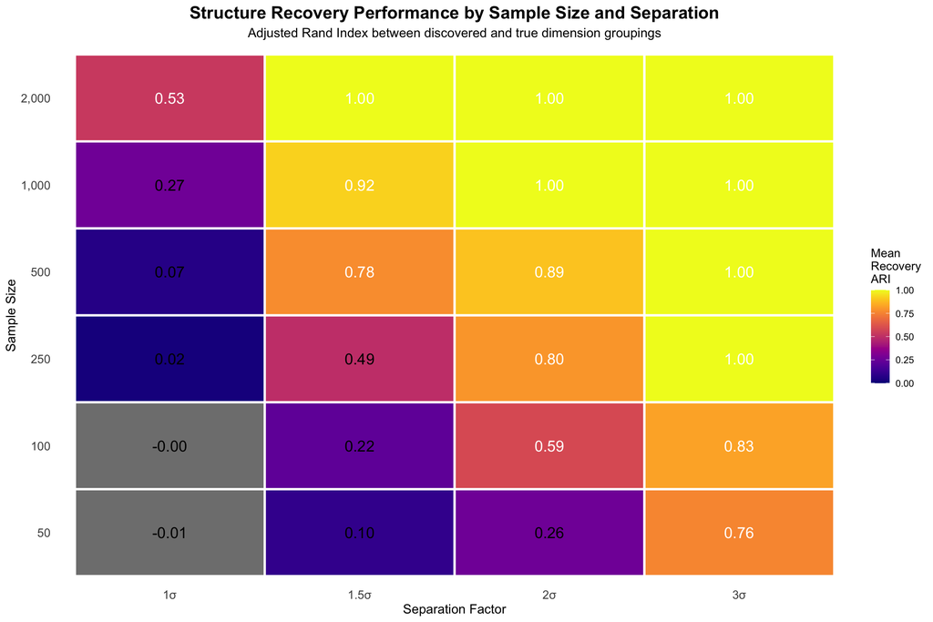

```r
# Create heatmap of mean recovery ARI
p_heatmap <- ggplot(summary_stats, aes(x = factor(separation_factor),
                                       y = factor(n_samples),
                                       fill = mean_ari)) +
  geom_tile(colour = "white", size = 1) +
  geom_text(aes(label = sprintf("%.2f", mean_ari)),
            colour = ifelse(summary_stats$mean_ari > 0.5, "white", "black"),
            size = 5) +
  scale_fill_viridis(name = "Mean\nRecovery\nARI",
                     limits = c(0, 1),
                     option = "plasma") +
  scale_x_discrete(labels = function(x) paste0(x, "σ")) +
  scale_y_discrete(labels = function(x) format(as.numeric(x), big.mark = ",")) +
  labs(title = "Structure Recovery Performance by Sample Size and Separation",
       subtitle = "Adjusted Rand Index between discovered and true dimension groupings",
       x = "Separation Factor",
       y = "Sample Size") +
  theme_minimal() +
  theme(plot.title = element_text(hjust = 0.5, size = 16, face = "bold"),
        plot.subtitle = element_text(hjust = 0.5, size = 12),
        axis.text = element_text(size = 11),
        axis.title = element_text(size = 12),
        legend.title = element_text(size = 11),
        panel.grid = element_blank())

print(p_heatmap)
```

## 4.3 Distribution of Recovery Performance

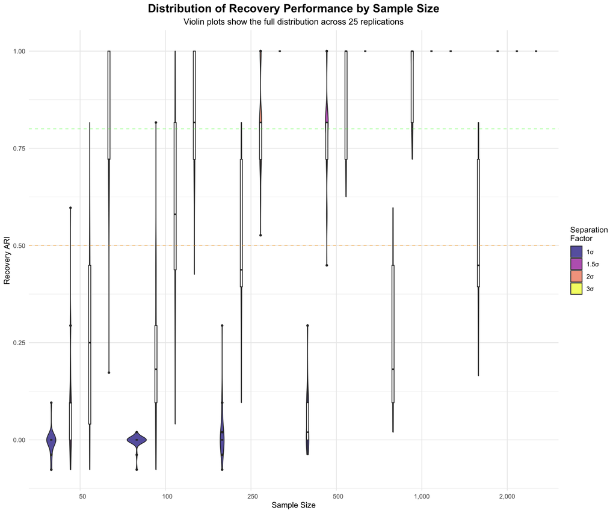

```r
# Create violin plots showing distribution at each condition
p_violin <- ggplot(all_results, aes(x = factor(n_samples), y = recovery_ari)) +
  geom_violin(aes(fill = factor(separation_factor)),
              position = position_dodge(width = 0.9),
              alpha = 0.7) +
  geom_boxplot(aes(group = interaction(n_samples, separation_factor)),
               position = position_dodge(width = 0.9),
               width = 0.1,
               outlier.size = 1) +
  scale_fill_viridis_d(name = "Separation\nFactor",
                       labels = function(x) paste0(x, "σ"),
                       option = "plasma") +
  scale_x_discrete(labels = function(x) format(as.numeric(x), big.mark = ",")) +
  labs(title = "Distribution of Recovery Performance by Sample Size",
       subtitle = "Violin plots show the full distribution across 25 replications",
       x = "Sample Size",
       y = "Recovery ARI") +
  theme_minimal() +
  theme(plot.title = element_text(hjust = 0.5, size = 16, face = "bold"),
        plot.subtitle = element_text(hjust = 0.5, size = 12),
        legend.position = "right") +
  geom_hline(yintercept = 0.8, linetype = "dashed", alpha = 0.5, colour = "green") +
  geom_hline(yintercept = 0.5, linetype = "dashed", alpha = 0.5, colour = "orange")

print(p_violin)
```

## 4.4 Sample Size Effect at Each Separation Level

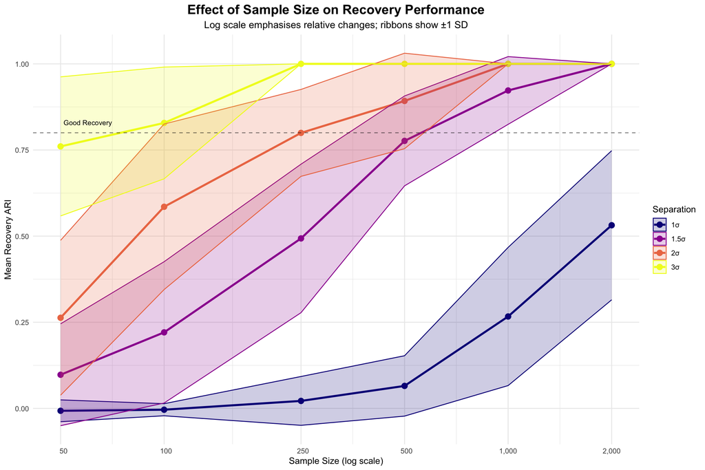

```r
# Create line plots showing sample size effect
p_lines <- ggplot(summary_stats, aes(x = n_samples, y = mean_ari,
                                     colour = factor(separation_factor))) +
  geom_line(size = 1.2) +
  geom_point(size = 3) +
  geom_ribbon(aes(ymin = mean_ari - sd_ari,
                  ymax = mean_ari + sd_ari,
                  fill = factor(separation_factor)),
              alpha = 0.2) +
  scale_x_log10(breaks = sample_sizes,
                labels = format(sample_sizes, big.mark = ",")) +
  scale_colour_viridis_d(name = "Separation",
                        labels = function(x) paste0(x, "σ"),
                        option = "plasma") +
  scale_fill_viridis_d(name = "Separation",
                      labels = function(x) paste0(x, "σ"),
                      option = "plasma") +
  labs(title = "Effect of Sample Size on Recovery Performance",
       subtitle = "Log scale emphasises relative changes; ribbons show ±1 SD",
       x = "Sample Size (log scale)",
       y = "Mean Recovery ARI") +
  theme_minimal() +
  theme(plot.title = element_text(hjust = 0.5, size = 16, face = "bold"),
        plot.subtitle = element_text(hjust = 0.5, size = 12),
        legend.position = "right") +
  geom_hline(yintercept = 0.8, linetype = "dashed", alpha = 0.5) +
  annotate("text", x = 60, y = 0.83, label = "Good Recovery", size = 3)

print(p_lines)
```

## 4.5 Bimodal Behaviour Analysis

[figure not shown]

```r
# Focus on the bimodal region (1.5σ)
bimodal_data <- all_results %>%
  filter(separation_factor == 1.5)

# Calculate bimodality metric (proportion in middle range)
bimodality_stats <- bimodal_data %>%
  group_by(n_samples) %>%
  summarise(
    prop_perfect = mean(recovery_ari > 0.9),
    prop_failed = mean(recovery_ari < 0.1),
    prop_middle = mean(recovery_ari >= 0.1 & recovery_ari <= 0.9),
    n_modes = ifelse(prop_middle < 0.2 & prop_perfect > 0.1 & prop_failed > 0.1, 2, 1),
    .groups = 'drop'
  )

# Create stacked bar plot
bimodal_long <- bimodality_stats %>%
  select(n_samples, prop_perfect, prop_failed, prop_middle) %>%
  pivot_longer(cols = starts_with("prop_"),
               names_to = "outcome",
               values_to = "proportion") %>%
  mutate(outcome = factor(outcome,
                         levels = c("prop_failed", "prop_middle", "prop_perfect"),
                         labels = c("Failed (ARI < 0.1)",
                                   "Intermediate",
                                   "Perfect (ARI > 0.9)")))

p_bimodal <- ggplot(bimodal_long, aes(x = factor(n_samples), y = proportion,
                                      fill = outcome)) +
  geom_bar(stat = "identity", width = 0.7) +
  scale_fill_manual(values = c("Failed (ARI < 0.1)" = "#E41A1C",
                              "Intermediate" = "#969696",
                              "Perfect (ARI > 0.9)" = "#4DAF4A"),
                   name = "Recovery\nOutcome") +
  scale_x_discrete(labels = function(x) format(as.numeric(x), big.mark = ",")) +
  labs(title = "Bimodal Behaviour at Critical Separation (1.5σ)",
       subtitle = "Distribution of outcomes shows transition from bimodal to unimodal failure",
       x = "Sample Size",
       y = "Proportion of Runs") +
  theme_minimal() +
  theme(plot.title = element_text(hjust = 0.5, size = 16, face = "bold"),
        plot.subtitle = element_text(hjust = 0.5, size = 12))

print(p_bimodal)
```

```r
# Print bimodality summary
cat("\nBimodality Analysis at 1.5σ Separation:\n")
```

```
##
## Bimodality Analysis at 1.5σ Separation:
```

```r
print(bimodality_stats)
```

```
## # A tibble: 6 × 5
##   n_samples prop_perfect prop_failed prop_middle n_modes
##       <dbl>        <dbl>       <dbl>       <dbl>   <dbl>
## 1        50         0           0.76        0.24       1
## 2       100         0           0.36        0.64       1
## 3       250         0           0.04        0.96       1
## 4       500         0.12        0           0.88       1
## 5      1000         0.6         0           0.4        1
## 6      2000         1           0           0          1
```

## 4.6 Critical Thresholds by Sample Size

```r
# Find critical thresholds for each sample size
threshold_analysis <- all_results %>%
  group_by(n_samples, separation_factor) %>%
  summarise(mean_ari = mean(recovery_ari), .groups = 'drop') %>%
  group_by(n_samples) %>%
  summarise(
    threshold_80 = max(separation_factor[mean_ari < 0.8], na.rm = TRUE),
    threshold_50 = max(separation_factor[mean_ari < 0.5], na.rm = TRUE),
    .groups = 'drop'
  )

# Handle cases where threshold is not found
threshold_analysis <- threshold_analysis %>%
  mutate(
    threshold_80 = ifelse(is.finite(threshold_80), threshold_80, NA),
    threshold_50 = ifelse(is.finite(threshold_50), threshold_50, NA)
  )

knitr::kable(threshold_analysis, digits = 1,
             caption = "Minimum Separation Required for Reliable Recovery",
             col.names = c("Sample Size",
                          "For 80% Recovery (σ)",
                          "For 50% Recovery (σ)"))
```

| Sample Size | For 80% Recovery (σ) | For 50% Recovery (σ) |
| --- | --- | --- |
| 50 | 3.0 | 2.0 |
| 100 | 2.0 | 1.5 |
| 250 | 2.0 | 1.5 |
| 500 | 1.5 | 1.0 |
| 1000 | 1.0 | 1.0 |
| 2000 | 1.0 | NA |

# 5. Key Findings

```r
# Extract specific findings for summary
n50_sep3 <- summary_stats %>%
  filter(n_samples == 50, separation_factor == 3.0) %>%
  pull(mean_ari)

n2000_sep1 <- summary_stats %>%
  filter(n_samples == 2000, separation_factor == 1.0) %>%
  pull(mean_ari)

bimodal_transition <- bimodality_stats %>%
  filter(n_modes == 1) %>%
  summarise(min_n = min(n_samples)) %>%
  pull(min_n)
```